# Generation of instance files for subproblems and combining them into problems

2024-05-29

## Generation of subproblems

We use the R package `gMOIP` to generate subproblems. A subproblem is generated such that all nondominated points is integer and in the hypercube $[0, 10000]^p$. A configuration is defined using:

- Number of objectives ($p$).
- Number of nondominated points (card).
- Generation method which is either
  - Points generated on the upper (u) part of a sphere resulting in many unsupported points (see Fig. 1).
  - Points generated between to hyperplanes in the middle (m) of the hypercube, resulting in both supported and unsupported points near to the hull (see Fig. 2).
  - Points generated on the lower (l) part of a sphere resulting in many supported points (see Fig. 1).

That is a subproblem can be identified using filename `sp-<p>-<card>-<gen-method>_<id>.json` where `id` denote the instance id for the same configuration.

[interactive chart not shown]

For each subproblem we calculate the statistics:

- Classification of points into supported extreme (se), supported non extreme (sne), unsupported (us).
- Number of
  - points (cardinality)
  - supported, extreme and unsupported
  - min and max value for each objective $i = 1,\ldots p$.
  - width $w_i$ = $max_i-min_i$ for each objective $i = 1,\ldots p$.

Let us try to generate a set of subproblems saved as json files in folder subproblems:

```r
pS <- 2:5 # p values
samplesS <- c(10, 50, 100, 150, 200, 300, 600) # nd points set size
dub <- 10 # number of duplicates for each configuration
deleteFiles()
saveSubproblems(pS, samplesS, dub, overwrite = F)
```

### A few plots

In total there are 840 subproblems.

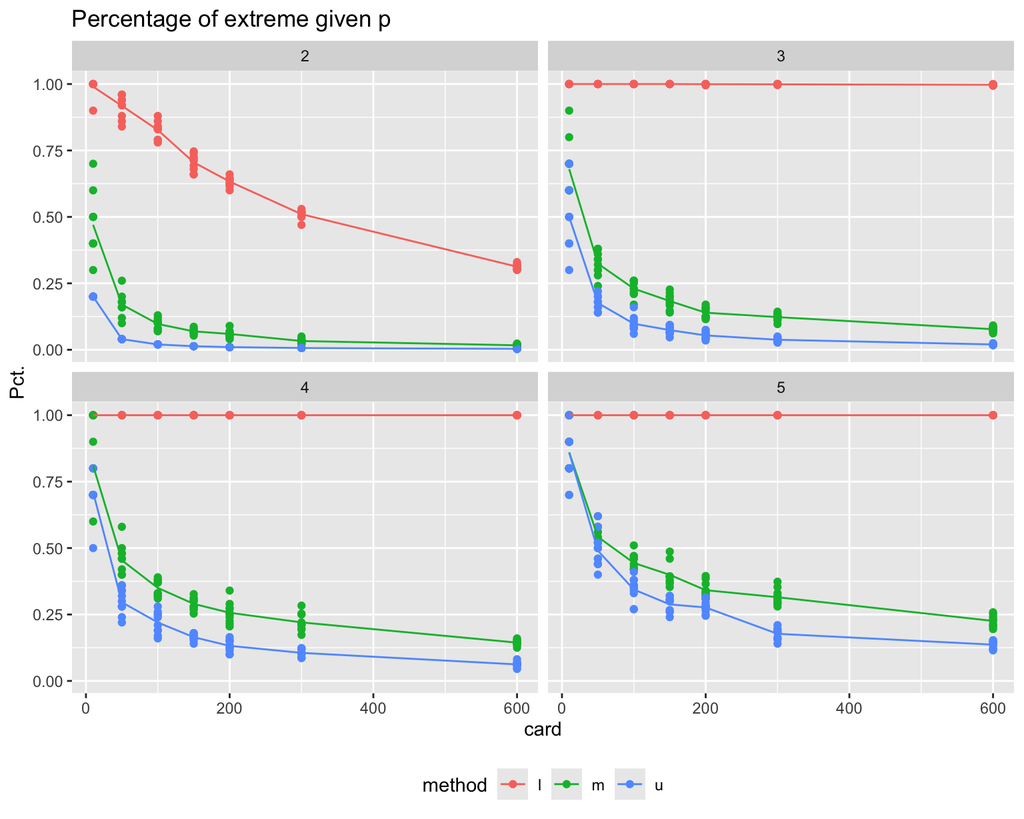

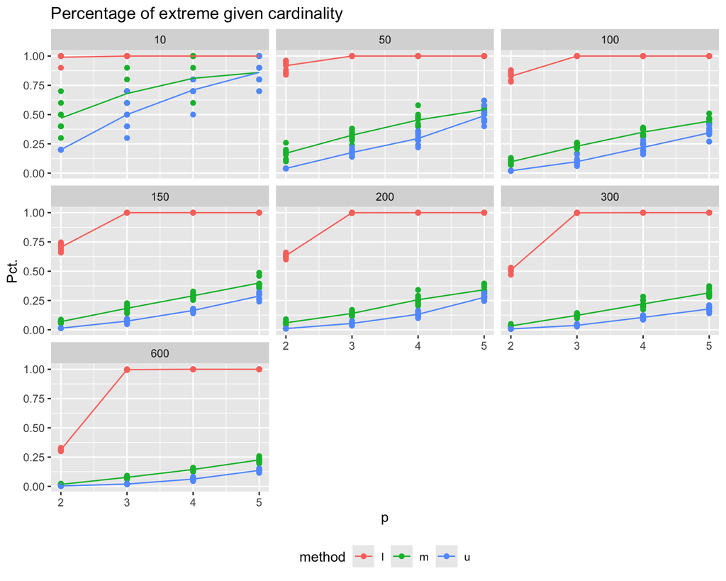

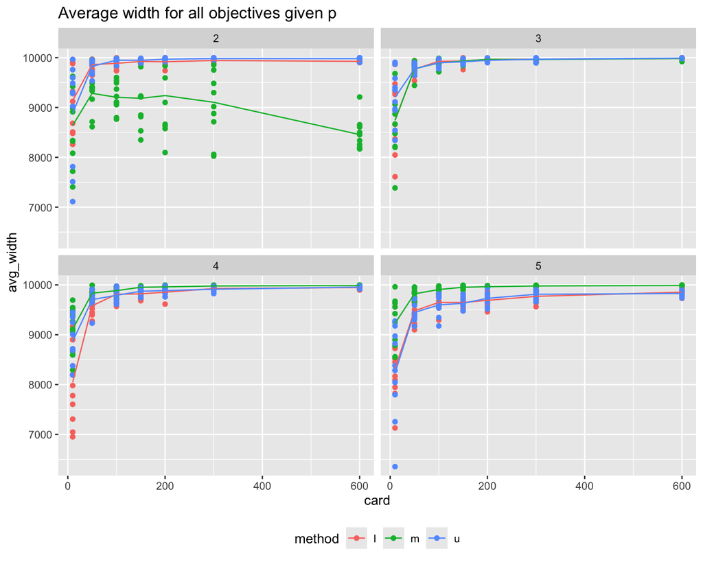

## Generation of problems

The problems generated consists of $2 \leq m\leq 5$ subproblems and is generated so provide a good test bed for a research question. The naming convention is `prob-<p>-<cards>-<gen-methods>_<m>_<id>.json`

The following instance/problem groups are generated given:

- $p=2,\ldots, 5$. [4 options]
- $m=2,\ldots 5$ where $m$ is the number of subproblems. [4 options]
- All subproblems have the same method config or half have method `u` and `l`. [4 options]
- Five instances for each config. [5 options]

```r
pS <- 2:5
mS <- 2:5
samplesS <- c(50, 100, 200, 300, 600) # nd points set size
methodS <- c("u", "l", "m", "ul")
dub <- 5 # number of duplicates for each configuration
saveProblemsAlg1(pS, mS, samplesS, methodS, dub, overwrite = F)
```

## Plots used in the paper

```
## # A tibble: 12 × 4
## # Groups:   method [3]
##    method     p      e       sne
##    <chr>  <dbl>  <dbl>     <dbl>
##  1 l          2 0.640  0.0178
##  2 l          3 0.999  0
##  3 l          4 1      0
##  4 l          5 1      0
##  5 m          2 0.0753 0.0149
##  6 m          3 0.179  0.0000333
##  7 m          4 0.285  0
##  8 m          5 0.374  0
##  9 u          2 0.016  0
## 10 u          3 0.0771 0
## 11 u          4 0.163  0
## 12 u          5 0.285  0
```

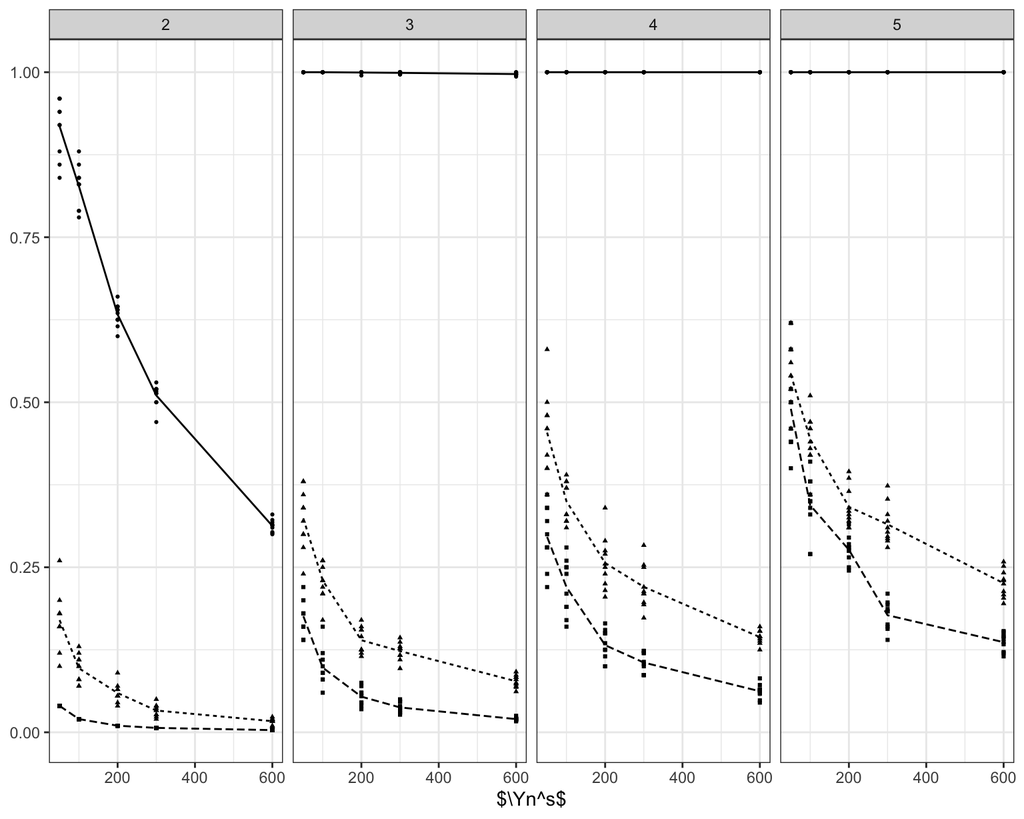

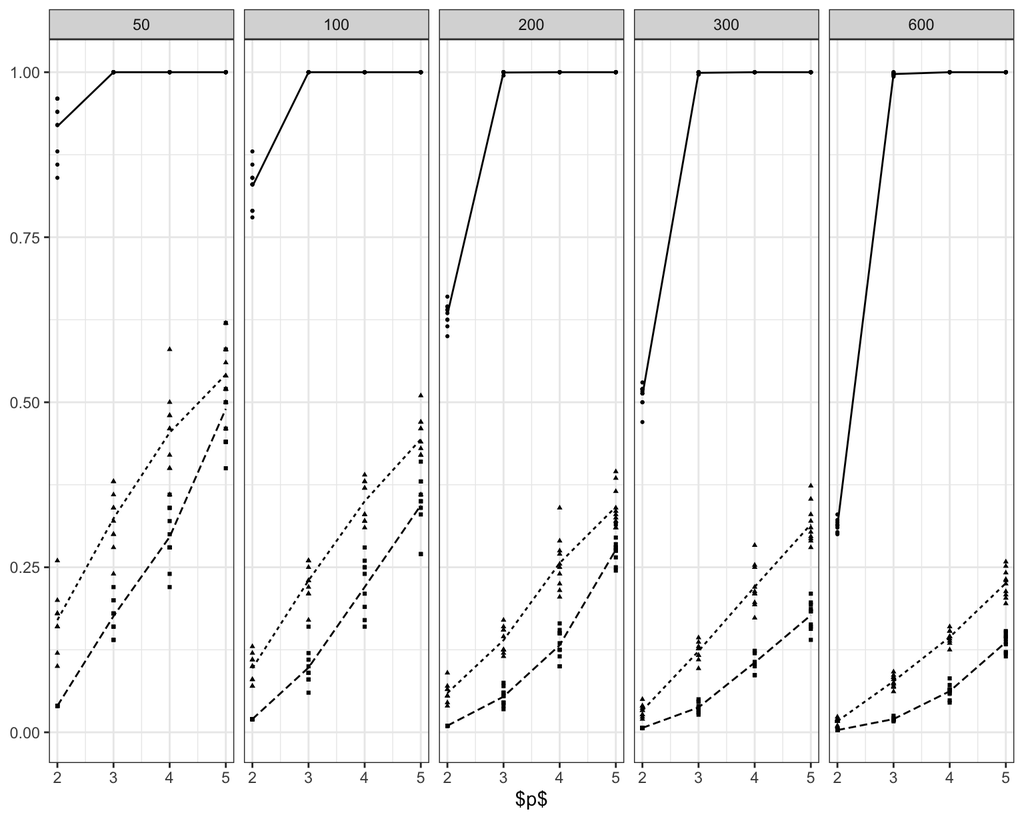

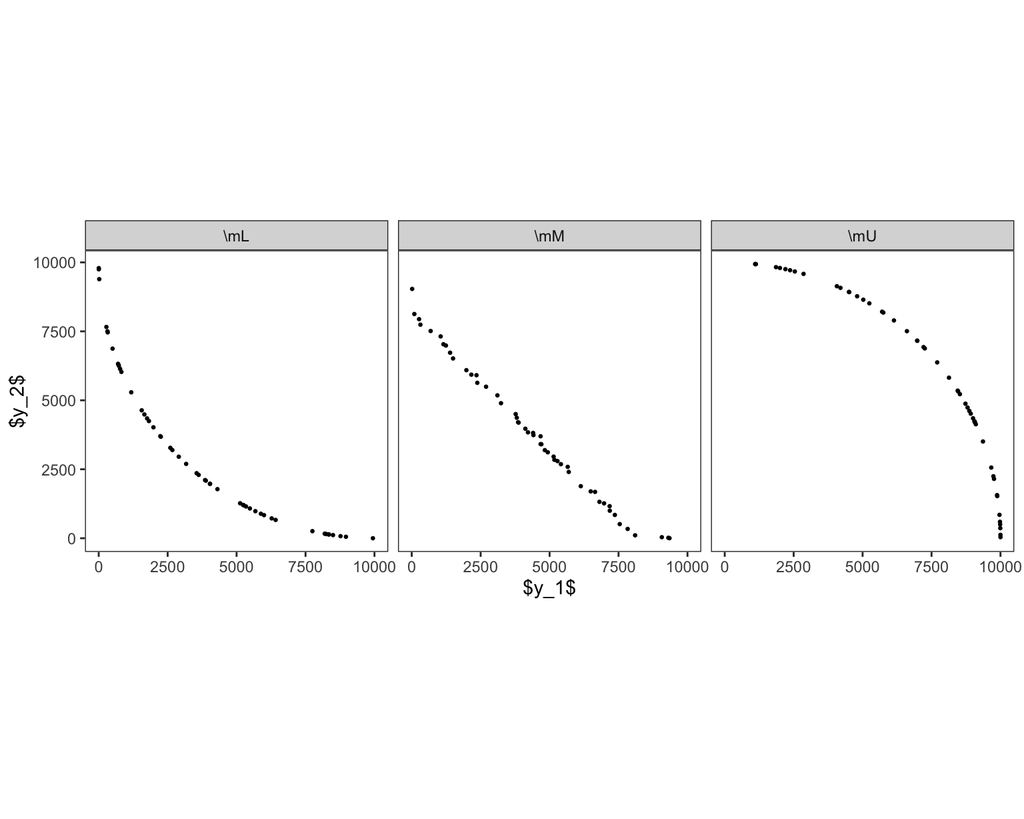